# Data Challenge - Part 2: Data Manipulation Using Pandas

**Author**: Emmanuel Ekwedike

**Date**: 08/18/23

## Introduction

This document presents eight fundamental data manipulation tasks using pandas. The dataset for these tasks includes two .csv files: "train.csv" and "test.csv," accessible at this [link](https://www.dropbox.com/s/niqs8pv5n55kwu0/Coding%20DS%20dataset.zip?dl=0)

The dataset comprises time-based air pollution measurements, alongside essential weather details like temperature and humidity. Additionally, it encompasses input readings from five sensors.

### Preamble

Import helpful libraries

```python
import os
import random
import numpy as np
import pandas as pd
import seaborn as sns
import matplotlib.pyplot as plt
from sklearn.metrics import confusion_matrix
from sklearn.model_selection import train_test_split
```

```python
def get_summary_stats(df_train, df_test ):
    """
    :param df_train:
    :param df_test:
    """
    summary_stats_train = df_train.describe()
    missing_data_train = df_train.isnull().sum()
    print(f"Summary Statistics: {train_filename}\n {summary_stats_train}")
    print(f"\nMissing Data: \n {missing_data_train}")

    summary_stats_test = df_test.describe()
    missing_data_test = df_test.isnull().sum()
    print(f"\nSummary Statistics: {test_filename}\n {summary_stats_test}")
    print(f"\nMissing Data: \n {missing_data_train}")

def read_data(train_filename, test_filename, base_path = "./Part Two Data/", display_stats = False):
    """
    :param train_filename:
    :param test_filename:
    :param base_path:
    :param display_stats:
    """
    train_path = os.path.join(base_path,train_filename)
    test_path = os.path.join(base_path,test_filename)
    df_train = pd.read_csv(train_path)
    df_test = pd.read_csv(test_path)
    if display_stats:
        get_summary_stats(df_train, df_test )
    return df_train, df_test
```

#### Load data

```python
train_filename, test_filename = "train.csv", "test.csv"
df_train, df_test = read_data(train_filename, test_filename)
```

### 1. Concat: vertically concatenate the two csvs into a new dataframe df_full; for missing values in the test set use a random selection of values in the same column from the train set.

```python
df_full = pd.concat([df_train, df_test], ignore_index=True, sort= False)
N_train = len(df_train)
fill_missing_values = lambda x: x.fillna(random.choice(x[:N_train]))
df_full = df_full.apply(fill_missing_values, axis=0)
df_full.tail(n=2)
```

|  | date_time | deg_C | relative_humidity | absolute_humidity | sensor_1 | sensor_2 | sensor_3 | sensor_4 | sensor_5 | target_carbon_monoxide | target_benzene | target_nitrogen_oxides |
| --- | --- | --- | --- | --- | --- | --- | --- | --- | --- | --- | --- | --- |
| 9356 | 2011-04-04 13:00:00 | 29.1 | 12.7 | 0.5139 | 1053.2 | 1009.0 | 702.0 | 1009.8 | 808.5 | 0.8 | 5.5 | 47.2 |
| 9357 | 2011-04-04 14:00:00 | 27.9 | 13.5 | 0.5028 | 1124.6 | 1078.4 | 608.2 | 1061.3 | 816.0 | 0.8 | 5.5 | 47.2 |

### 2. Filter: on df_full select only the weekdays, where the relative humidity is >50 and abso <1.4 denote this df_filtered.

```python
#Create a weekday column
df_full['date_time'] = pd.to_datetime(df_full['date_time'])
df_full['weekday'] = df_full['date_time'].dt.day_name()

#Conditions:
cond1 = ~df_full["weekday"].isin(["Sunday", "Saturday"])
cond2 = df_full["relative_humidity"] > 50
cond3 = df_full["absolute_humidity"] < 1.4

#Filter
df_filtered = df_full[cond1 & cond2 & cond3].copy()
df_filtered = df_filtered.iloc[:, df_filtered.columns != 'weekday']
df_filtered.head(n=2)
```

|  | date_time | deg_C | relative_humidity | absolute_humidity | sensor_1 | sensor_2 | sensor_3 | sensor_4 | sensor_5 | target_carbon_monoxide | target_benzene | target_nitrogen_oxides |
| --- | --- | --- | --- | --- | --- | --- | --- | --- | --- | --- | --- | --- |
| 2 | 2010-03-10 20:00:00 | 12.6 | 56.2 | 0.7502 | 1331.9 | 929.6 | 1060.2 | 1586.1 | 1117.0 | 2.2 | 9.2 | 127.1 |
| 3 | 2010-03-10 21:00:00 | 11.0 | 62.4 | 0.7867 | 1321.0 | 929.0 | 1102.9 | 1536.5 | 1263.2 | 2.2 | 9.7 | 177.2 |

### 3. Apply: on df_filtered perform sensor 2 * sensor 3 if sensor 4 < MEDIAN VALUE, else sensor 2.* sensor 4 - average of that calendar month value

```python
# Calculate the median value of 'sensor_4' and the average of 'sensor_4' for each calendar month
median_value = df_filtered['sensor_4'].median()
df_filtered['average_sensor_4'] = df_filtered.groupby(df_filtered['date_time'].dt.to_period('M'))['sensor_4'].transform('mean')

# The given function for combining the sensors
combined_sensor_function = lambda row: row['sensor_2'] * row['sensor_3'] if row['sensor_4'] < median_value else row['sensor_2'] * row['sensor_4'] - row['average_sensor_4']
df_filtered['new_sensor'] = df_filtered.apply(combined_sensor_function, axis=1)
print(df_filtered.head(n=2))
```

```
            date_time  deg_C  relative_humidity  absolute_humidity  sensor_1  \
2 2010-03-10 20:00:00   12.6               56.2             0.7502    1331.9
3 2010-03-10 21:00:00   11.0               62.4             0.7867    1321.0

   sensor_2  sensor_3  sensor_4  sensor_5  target_carbon_monoxide  \
2     929.6    1060.2    1586.1    1117.0                     2.2
3     929.0    1102.9    1536.5    1263.2                     2.2

   target_benzene  target_nitrogen_oxides  average_sensor_4    new_sensor
2             9.2                   127.1       1558.833333  1.472880e+06
3             9.7                   177.2       1558.833333  1.425850e+06
```

### 4. Groupby: on df_fill table find the min/max/mean/count temp over each day as a table

```python
# Group by date and calculate the required statistics
df_full['date'] = df_full['date_time'].dt.date
temp_stats_table = df_full.groupby('date')['deg_C'].agg(['min', 'max', 'mean', 'count'])
temp_stats_table = temp_stats_table.reset_index()
print(temp_stats_table)
```

```
           date   min   max       mean  count
0    2010-03-10  11.0  13.2  12.166667      6
1    2010-03-11   7.7  11.4   9.762500     24
2    2010-03-12   5.7  16.2  11.133333     24
3    2010-03-13   6.2  19.0  12.779167     24
4    2010-03-14  10.0  22.7  15.800000     24
..          ...   ...   ...        ...    ...
386  2011-03-31  12.0  23.9  17.583333     24
387  2011-04-01  12.6  20.4  15.737500     24
388  2011-04-02  10.6  22.6  15.458333     24
389  2011-04-03   8.3  30.9  18.341667     24
390  2011-04-04   9.1  29.1  16.973333     15

[391 rows x 5 columns]
```

### 5. Create a column on df_full:

#### a. read in a dict : 5 unequal splits, 0-0.2, 0.2-0.5, 0.5-0.8, 0.8-0.85, 1 - make it generic

```python
# Define the class ranges and labels dictionary
class_ranges = {
    'class1': [0, 0.2],
    'class2': [0.2, 0.5],
    'class3': [0.5, 0.8],
    'class4': [0.8, 0.85],
    'class5': [0.85, 1]
}
```

#### b. apply to sensor_1 = name it Truth, apply to sensor_2 = name it Predicted

```python
# Normalize the values to the [0, 1] range
min_value_sensor_1 = min(df_full['sensor_1'])
max_value_sensor_1 = max(df_full['sensor_1'])
min_value_sensor_2 = min(df_full['sensor_2'])
max_value_sensor_2 = max(df_full['sensor_2'])
df_full['normalized_sensor_1'] = (df_full['sensor_1'] - min_value_sensor_1) / (max_value_sensor_1 - min_value_sensor_1)
df_full['normalized_sensor_2'] = (df_full['sensor_2'] - min_value_sensor_2) / (max_value_sensor_2 - min_value_sensor_2)

# Create a function to map normalized values to class labels
def map_to_class(value):
    for class_name, (start, end) in class_ranges.items():
        if start <= value <= end:
            return class_name
    return None

df_full['Truth'] = df_full['normalized_sensor_1'].apply(map_to_class)
df_full['Predicted'] = df_full['normalized_sensor_2'].apply(map_to_class)

#clean up dataframe
df_full = df_full.drop(['normalized_sensor_1', 'normalized_sensor_2'], axis=1)
df_full.head(n=2)
```

|  | date_time | deg_C | relative_humidity | absolute_humidity | sensor_1 | sensor_2 | sensor_3 | sensor_4 | sensor_5 | target_carbon_monoxide | target_benzene | target_nitrogen_oxides | weekday | date | Truth | Predicted |
| --- | --- | --- | --- | --- | --- | --- | --- | --- | --- | --- | --- | --- | --- | --- | --- | --- |
| 0 | 2010-03-10 18:00:00 | 13.1 | 46.0 | 0.7578 | 1387.2 | 1087.8 | 1056.0 | 1742.8 | 1293.4 | 2.5 | 12.0 | 167.7 | Wednesday | 2010-03-10 | class3 | class2 |
| 1 | 2010-03-10 19:00:00 | 13.2 | 45.3 | 0.7255 | 1279.1 | 888.2 | 1197.5 | 1449.9 | 1010.9 | 2.1 | 9.9 | 98.9 | Wednesday | 2010-03-10 | class2 | class2 |

### 6. Merge: starting from df_full let’s look at the differences to the same day last year for available days

#### a. How many days overlap in the two latest years?

**Assumption**: I interpret the question as determining the count of distinct days within the last two years.

```python
df_full['date_time'] = pd.to_datetime(df_full['date_time'])

df_full = df_full.sort_values(by='date')
latest_years = df_full['date_time'].dt.year.unique()[-2:] # 2010 and 2011
# Filter the DataFrame for the two latest years
latest_years_df = df_full[df_full['date_time'].dt.year.isin(latest_years)]

overlap_days = latest_years_df['date'].nunique()
print("Number of overlapping days in the two latest years:", overlap_days)
```

```
Number of overlapping days in the two latest years: 391
```

#### b. What is the average of the daily difference of abs humidity?

```python
df_full = df_full.sort_values(by='date_time')
df_full['abs_humidity_diff'] = df_full['absolute_humidity'].diff()
df_full['abs_humidity_diff'] = df_full['abs_humidity_diff'].abs()
daily_avg_diff = df_full.groupby(df_full['date_time'].dt.date)['abs_humidity_diff'].mean()
overall_avg_diff = daily_avg_diff.mean()
overall_avg_diff
```

```
0.03143258439897698
```

#### c. What is the difference in average of sensor 1 data between the two years?

```python
# df_full['date_time'] = pd.to_datetime(df_full['date_time'])
df_full['year'] = df_full['date_time'].dt.year
# Calculate the average of 'sensor_1' data for each year
yearly_avg_sensor1 = df_full.groupby('year')['sensor_1'].mean()
# Calculate the difference in the average between the two years
difference_in_avg = yearly_avg_sensor1.iloc[-1] - yearly_avg_sensor1.iloc[-2]

print("Difference in average of sensor 1 data between the two years:", difference_in_avg)
```

```
Difference in average of sensor 1 data between the two years: 14.965821708685326
```

### 7. Plots on df_full:

#### a. histogram of absolute humidity

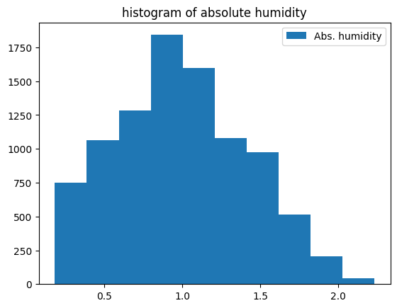

```python
plt.hist(df_full["absolute_humidity"], label="Abs. humidity")
plt.legend()
plt.title("histogram of absolute humidity")
plt.show()
```

#### b. sensor 1 - 5 histograms overlaid on same figure

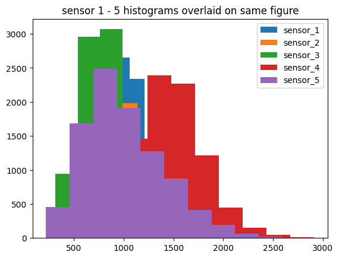

```python
plt.hist(df_full["sensor_1"], label="sensor_1")
plt.hist(df_full["sensor_2"], label="sensor_2")
plt.hist(df_full["sensor_3"], label="sensor_3")
plt.hist(df_full["sensor_4"], label="sensor_4")
plt.hist(df_full["sensor_5"], label="sensor_5")

plt.legend()
plt.title("sensor 1 - 5 histograms overlaid on same figure")
plt.show()
```

#### c. scatter plot of sensor 1 vs sensor 2 coloured blue if weekday, red otherwise

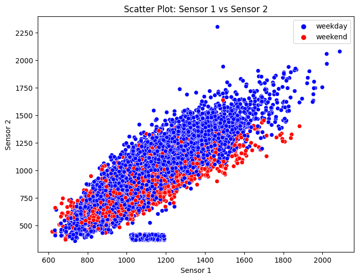

```python
df_full['is_weekday'] =  df_full['date_time'].dt.dayofweek < 5
df_full['hue'] =  df_full['is_weekday'].map({True:"weekday", False:"weekend"})

plt.figure(figsize=(8, 6))
ax = sns.scatterplot(data=df_full, x='sensor_1', y='sensor_2', hue='hue', palette={"weekday": 'blue', "weekend": 'red'})
plt.title("Scatter Plot: Sensor 1 vs Sensor 2")
plt.xlabel("Sensor 1")
plt.ylabel("Sensor 2")
ax.legend().set_title("")
```

#### d. correlation matrix of all sensors against each other with histograms along diag

**Assumption** I interpreted this question as referring to a correlogram.

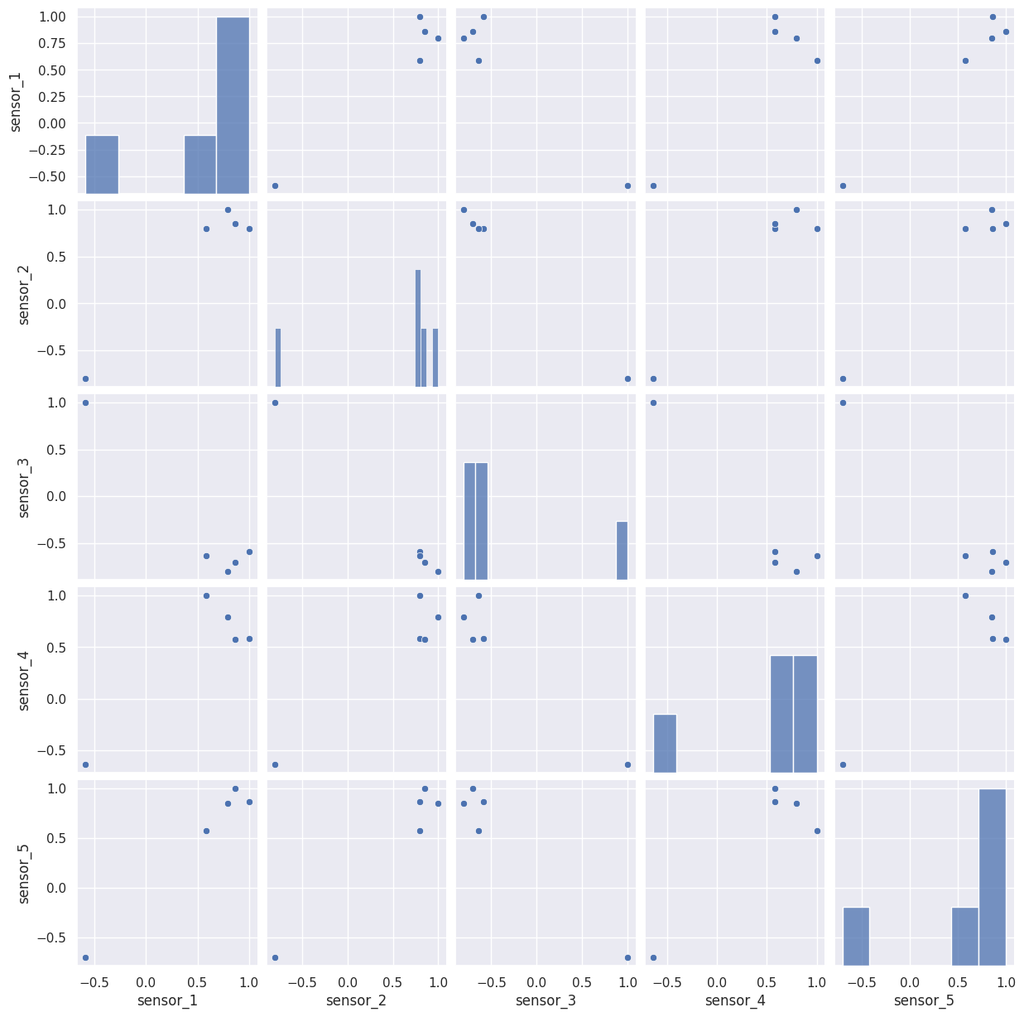

```python
correlation_matrix = df_full.loc[:,["sensor_1","sensor_2","sensor_3", "sensor_4", "sensor_5"]].corr()  # Exclude date_time, weekday, Truth, and Predicted
sns.set(rc={'figure.figsize':(8,8)})
sns.pairplot(correlation_matrix)
# plt.show()
```

### e. confusion matrix of predicted vs truth

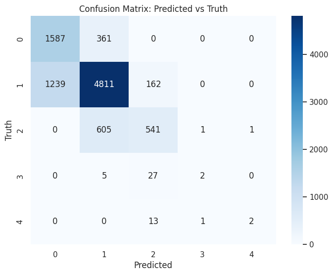

```python
conf_matrix = confusion_matrix(df_full['Truth'], df_full['Predicted'])
plt.figure(figsize=(8, 6))
sns.heatmap(conf_matrix, annot=True, fmt='d', cmap='Blues')
plt.title("Confusion Matrix: Predicted vs Truth")
plt.xlabel("Predicted")
plt.ylabel("Truth")
plt.show()
```

### 8. Create data split: 70%/30% split of the data from the train.csv ensure that each day is not split between sets

```python
daily_date_index = df_full.groupby('date').agg({'sensor_1': 'mean'}).index
train_days, test_days = train_test_split(daily_date_index, test_size=0.3, shuffle=False) # Note: we are spliting the date_index

# Filter original hourly dataframe based on train and test days
train_data = df_full[df_full['date'].isin(train_days)]
test_data = df_full[df_full['date'].isin(test_days)]
display(train_data.tail(n=2))
display(test_data.head(n=2))
# Print the shape of the splits
print("Training data shape:", train_data.shape)
print("Testing data shape:", test_data.shape)
```

|  | date_time | deg_C | relative_humidity | absolute_humidity | sensor_1 | sensor_2 | sensor_3 | sensor_4 | sensor_5 | target_carbon_monoxide | target_benzene | target_nitrogen_oxides | weekday | date | Truth | Predicted | abs_humidity_diff | year | is_weekday | hue |
| --- | --- | --- | --- | --- | --- | --- | --- | --- | --- | --- | --- | --- | --- | --- | --- | --- | --- | --- | --- | --- |
| 6532 | 2010-12-07 22:00:00 | 15.1 | 62.3 | 1.0216 | 1195.0 | 972.5 | 671.8 | 1304.6 | 1225.0 | 2.5 | 10.8 | 330.2 | Tuesday | 2010-12-07 | class2 | class2 | 0.0307 | 2010 | True | weekday |
| 6533 | 2010-12-07 23:00:00 | 15.3 | 56.4 | 1.0033 | 1144.3 | 922.5 | 705.6 | 1325.1 | 1188.6 | 1.9 | 7.5 | 256.2 | Tuesday | 2010-12-07 | class2 | class2 | 0.0183 | 2010 | True | weekday |

|  | date_time | deg_C | relative_humidity | absolute_humidity | sensor_1 | sensor_2 | sensor_3 | sensor_4 | sensor_5 | target_carbon_monoxide | target_benzene | target_nitrogen_oxides | weekday | date | Truth | Predicted | abs_humidity_diff | year | is_weekday | hue |
| --- | --- | --- | --- | --- | --- | --- | --- | --- | --- | --- | --- | --- | --- | --- | --- | --- | --- | --- | --- | --- |
| 6534 | 2010-12-08 00:00:00 | 14.2 | 61.1 | 1.0045 | 1015.6 | 803.7 | 765.0 | 1194.1 | 1018.6 | 1.7 | 6.8 | 180.4 | Wednesday | 2010-12-08 | class2 | class2 | 0.0012 | 2010 | True | weekday |
| 6535 | 2010-12-08 01:00:00 | 15.3 | 62.7 | 1.0031 | 1077.7 | 890.2 | 790.8 | 1279.1 | 994.6 | 1.8 | 7.1 | 184.8 | Wednesday | 2010-12-08 | class2 | class2 | 0.0014 | 2010 | True | weekday |

```
Training data shape: (6534, 20)
Testing data shape: (2824, 20)
```

The split is non-overlapping.

### Conclusion

In conclusion, this document has outlined eight fundamental data manipulation tasks utilizing the pandas library. The tasks are executed on a dataset consisting of two .csv files, namely "train.csv" and "test.csv," accessible through the provided link. This dataset encompasses time-based air pollution measurements, crucial weather information such as temperature and humidity, and input readings from five sensors. The tasks covered in this document showcase the versatility and power of pandas for handling and analyzing such comprehensive and multi-dimensional datasets.